# b03705027 鄭從德 hw6 Part b

```r
load('50kpred.rdata')
library('e1071')
library('dummies')
library('glmnet')
library('randomForest')
```

## My Functions

```r
replace_with_dummy = function(df, cols){
  dummydf = dummy(cols)
  df = cbind(df, dummydf)
  return(df)
}

get_error_rate = function(predictions, y){
  tf_array = predictions>0.5
  t=0
  f=0
  for(i in 1:length(tf_array)){
    if( (tf_array[i]&&y[i]) || (tf_array[i]==FALSE && y[i]==FALSE )){
      t = t+1
    }else{
      f = f+1
    }
  }
  return(f/(t+f))
}
```

## Problem 1

```r
df_x_train_all = raw1[,1:14]
df_y_train_all = raw1[,16]

counter = c()
pro = c()
for(i in 1:10){
  counter[i] = 0
  pro[i]=0
}
for(i in 1:nrow(df_x_train_all)){
  classico = floor(df_x_train_all$age[i]/10)
  if(df_y_train_all[i]==TRUE){
    pro[classico] = (pro[classico]*counter[classico] + 1)/(counter[classico]+1)
  }
  else{
    pro[classico] = (pro[classico]*counter[classico])/(counter[classico]+1)
  }
  counter[classico] = counter[classico] + 1
}

print(pro)
```

```
##  [1] 0.0007304602 0.0664868510 0.2730483498 0.3756521739 0.3913978495
##  [6] 0.2766217870 0.2156862745 0.1071428571 0.2000000000 0.0000000000
```

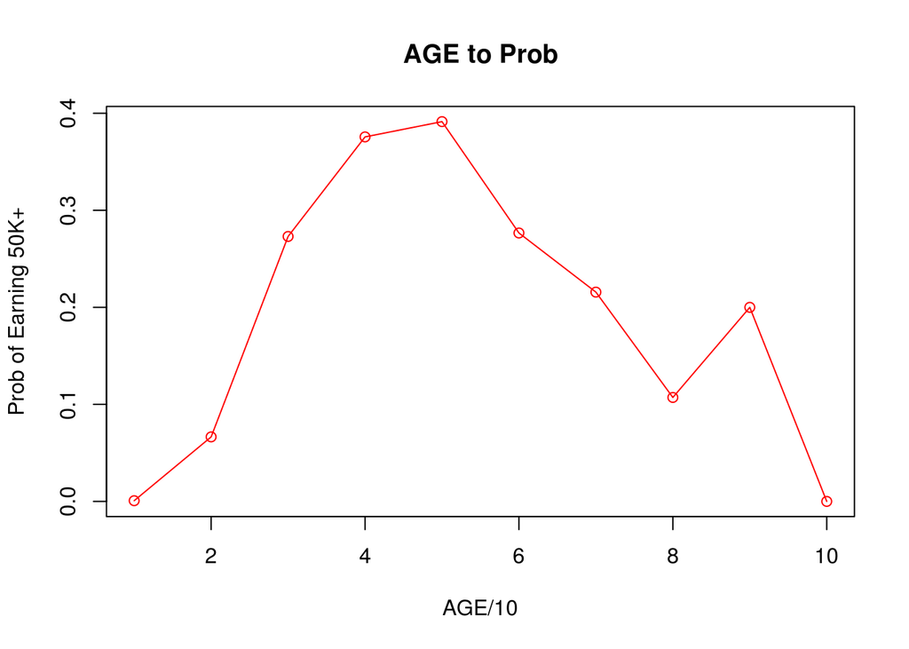

```r
plot(y=pro, x=c(1,2,3,4,5,6,7,8,9,10) ,type = "o",col = "red", xlab = 'AGE/10', ylab = "Prob of Earning 50K+",
       main = 'AGE to Prob')
```

In this question, I chose ‘AGE’ as the key variable. We can see from the line chart that nearly 40% people around 40~60 year-old make more than 50K a year. This totally makes sense since most people reach the peak of their careers around this age. There’s another peak at 90+ year-old, I think these datapoints are from extremely rich people that receive better medical care or just have a better life after retire so they tend to live longer.

## Problem 2: Ridge Regression

### Part 1 Preprocessing

```r
# Normalize Data and create dummies
# COMBINE ALL
df_x_train = raw1[,1:14]
df_y_train = raw1[,16]
df_x_test = raw_test[,1:14]
df_y_test = raw_test[,16]
df_x = rbind(df_x_train, df_x_test)

df_x$age = scale(df_x$age)
df_x$fnlwgt = scale(df_x$fnlwgt)
df_x$education_num = scale(df_x$education_num)
df_x$capital_gain = scale(df_x$capital_gain)
df_x$capital_loss = scale(df_x$capital_loss)
df_x$hours_per_week = scale(df_x$hours_per_week)

## Replace with dummy
df_x = replace_with_dummy(df_x, df_x$sex)
df_x = replace_with_dummy(df_x, df_x$workclass)
df_x = replace_with_dummy(df_x, df_x$marital_status)
df_x = replace_with_dummy(df_x, df_x$occupation)
df_x = replace_with_dummy(df_x, df_x$relationship)
df_x = replace_with_dummy(df_x, df_x$race)
df_x = replace_with_dummy(df_x, df_x$native_country)


# Get rid of original columns
df_x <- subset(df_x, select = -sex)
df_x <- subset(df_x, select = -workclass)
df_x <- subset(df_x, select = -education)
df_x <- subset(df_x, select = -marital_status)
df_x <- subset(df_x, select = -occupation)
df_x <- subset(df_x, select = -relationship)
df_x <- subset(df_x, select = -race)
df_x <- subset(df_x, select = -native_country)

cSumsdf = colSums(df_x)

for(col in colnames(df_x)){
  if(cSumsdf[col]<50){
    if(grepl('df_x', col)){
      df_x = df_x[, names(df_x)!= col]
    }
  }
}

df_x_train = df_x[1:30162,]
df_x_test = df_x[30163:45222,]

## Define Subtraining and Tunning Set
x_tunning = df_x_train[folds==10,]
x_subtraining = df_x_train[folds!=10,]
y_tunning = df_y_train[folds==10]
y_subtraining = df_y_train[folds!=10]
```

## Ridge Regression

```r
fit = cv.glmnet(x=as.matrix(x_subtraining), y=y_subtraining, family="binomial")
opt_lambda <- fit$lambda.min
rrfit <- fit$glmnet.fit
summary(rrfit)
```

```
##            Length Class     Mode
## a0           77   -none-    numeric
## beta       6776   dgCMatrix S4
## df           77   -none-    numeric
## dim           2   -none-    numeric
## lambda       77   -none-    numeric
## dev.ratio    77   -none-    numeric
## nulldev       1   -none-    numeric
## npasses       1   -none-    numeric
## jerr          1   -none-    numeric
## offset        1   -none-    logical
## classnames    2   -none-    character
## call          4   -none-    call
## nobs          1   -none-    numeric
```

```r
rrprediction <- predict(rrfit, s = opt_lambda, newx = as.matrix(df_x_test), type='response')
rr_testing_for_stacking = rrprediction>0.5
e = get_error_rate(rrprediction, df_y_test)
print(e)
```

```
## [1] 0.15166
```

## Problem 3. Random Forest

```r
rm = randomForest(x=as.matrix(x_subtraining), y=as.matrix(y_subtraining), xtest=as.matrix(df_x_test), ytest=as.matrix(df_y_test), keep.forest=TRUE)
rf_testing_for_stacking = rm$test$predicted>0.5
e2 = get_error_rate(rm$test$predicted, df_y_test)
print('Testing Error Rate:')
```

```
## [1] "Testing Error Rate:"
```

```r
print(e2)
```

```
## [1] 0.1435591
```

The Testing Error Rate on Random Forest is 14.34%

## Problem 4. SVM

```r
svmModel = svm(x=as.matrix(x_subtraining), y=as.vector(y_subtraining), type='one-classification')
svmPredictions = predict(svmModel, as.matrix(df_x_test))
t=0
f=0
for(i in 1:length(svmPredictions)){
  if((svmPredictions[i] && df_y_test[i]) || (svmPredictions==FALSE && df_y_test[i]==FALSE)){
      t=t+1
  }else{
    f=f+1
  }
}
print('Testing Error Rate:')
```

```
## [1] "Testing Error Rate:"
```

```r
print((f/(f+t)))
```

```
## [1] 0.1183931
```

## Problem 5. Stacking

```r
model_rr_pred_v = predict(rrfit, s = opt_lambda, newx = as.matrix(x_tunning), type='response')
model_rr_pred_b = model_rr_pred_v>0.5
model_rf_pred_v = predict(rm, as.matrix(x_tunning))
model_rf_pred_b = model_rf_pred_v > 0.5
model_svm_pred_b = predict(svmModel, as.matrix(x_tunning), probability=TRUE)
model_svm_pred_v = as.integer(model_svm_pred_b)
# My training X:
stacking_x = data.frame('ridge'=model_rr_pred_b, "randomForest"=model_rf_pred_b, "svm"=model_svm_pred_b)
# Testing X for stacking
stacking_x_test = data.frame('ridge'=rr_testing_for_stacking, "randomForest"=rf_testing_for_stacking, "svm"=svmPredictions)
```

### Model(A) Ridge Regression:

```r
rrfit_2 = cv.glmnet(x=as.matrix(stacking_x), y=y_tunning, family="binomial")
opt_lambda_2 <- rrfit_2$lambda.min
rrfit_2 <- rrfit_2$glmnet.fit
modela_pred <- predict(rrfit_2, s = opt_lambda, newx = as.matrix(stacking_x_test), type='response')
ea = get_error_rate(modela_pred, df_y_test)
print(ea)
```

```
## [1] 0.1435591
```

Testing Error is 14.34%

### Model(B) Logistic Regression:

```r
y_tunning_df = data.frame('y'=y_tunning)
mydata = cbind(y_tunning, stacking_x)
fit <- glm(y_tunning~X1+randomForest+svm,data=mydata,family=binomial())
summary(fit)
```

```
##
## Call:
## glm(formula = y_tunning ~ X1 + randomForest + svm, family = binomial(),
##     data = mydata)
##
## Deviance Residuals:
##     Min       1Q   Median       3Q      Max
## -1.9516  -0.4484  -0.4454  -0.4454   2.1724
##
## Coefficients:
##                  Estimate Std. Error z value Pr(>|z|)
## (Intercept)      -2.26057    0.09066 -24.936   <2e-16 ***
## X1TRUE            1.52924    0.15451   9.897   <2e-16 ***
## randomForestTRUE  2.46077    0.14981  16.426   <2e-16 ***
## svmTRUE           0.01377    0.11375   0.121    0.904
## ---
## Signif. codes:  0 '***' 0.001 '**' 0.01 '*' 0.05 '.' 0.1 ' ' 1
##
## (Dispersion parameter for binomial family taken to be 1)
##
##     Null deviance: 3311.8  on 2952  degrees of freedom
## Residual deviance: 2125.3  on 2949  degrees of freedom
## AIC: 2133.3
##
## Number of Fisher Scoring iterations: 4
```

```r
modelb_pred = predict(fit, newdata = stacking_x_test)
eb = get_error_rate(modelb_pred, df_y_test)
print(eb)
```

```
## [1] 0.1454847
```

### Model(C) Simple Average

```r
sa_pred = rrprediction + rm$test$predicted + svmPredictions > 1.5
get_error_rate(sa_pred, df_y_test)
```

```
## [1] 0.1804781
```

### Model(D) VOTE!

```r
voting = as.integer(rr_testing_for_stacking) + as.integer(rf_testing_for_stacking ) + as.integer(svmPredictions)
voting = voting>1.5
ed = get_error_rate(voting, df_y_test)
print(ed)
```

```
## [1] 0.149004
```

### Conclusion:

Among All stacking methods, Ridge Regression gave a better result. I think it’s explainable because the `voting method` gives all the three models the same weight, on the other hand, adding regression in stacking procedure means a small training process that should yield better results.

In this question, all the three original models performs pretty good, but one of the model perform much better than the other two (89% to 85% accuracy).Stacking the three models could potentially bring bias to the SVM model, which cause the higher error rate. The stacking method should have a better performance when the three models yields similar result.

Also, in this question, the tunning set is relatively small, so only using the tunning set to find the stacking regression parameters may not be a good idea compares to considering all the training set.